# Graphical Presentations

We would like to be able to get a quick overview of our data. One way to do this is with graphs.

A **bar plot** represents categorical data with bars. Each bar’s height is based on the number of observations in that category.

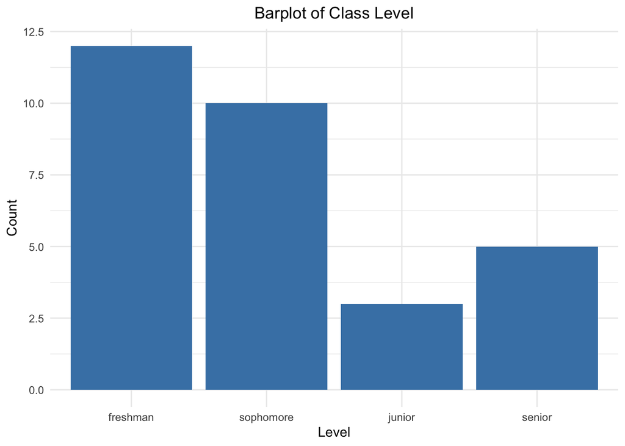

The bar plot above shows the class level breakdown for students in an Introductory Statistics course. Based on the plot, there are 5 seniors. How many sophomores are there? Freshman?

A **scatterplot** shows the relationship between two (numeric) variables.

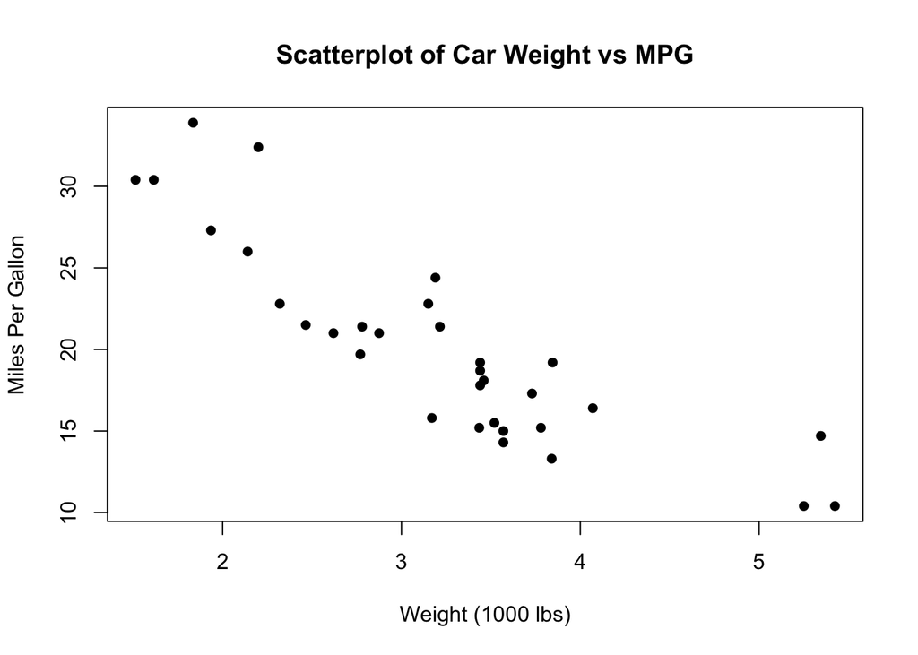

At a glance, we can see that (in general) heavier cars have lower MPG.

Good data visualization is *easy to interpret*! Data visualization should have labels: title, axis labels, numbers/categories clearly marked, and a legend if necessary.

We may also use graphs to examine the **distribution** of the data. A distribution relates values/categories to how often they occur. Think of distributing treats among a group of dogs. We could distribute the treats evenly or based on each dog’s behavior/tricks.

A **dot plot** is a single-variable scatterplot.

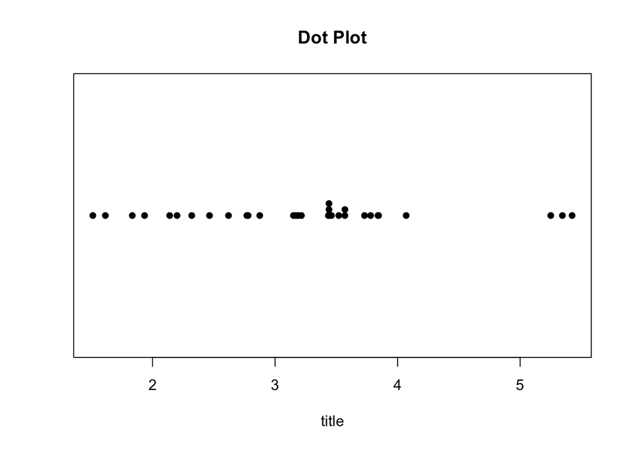

We will see more graphical presentations as we move through this module.

**[Next up: Frequency Distributions](https://lgpcappiello.github.io/teaching/IntroStats/descriptives/frequency.html) | [Back to: Experimental Design](https://lgpcappiello.github.io/teaching/IntroStats/descriptives/design.html) | [Return to Course Notes Homepage](https://lgpcappiello.github.io/teaching/IntroStats)**